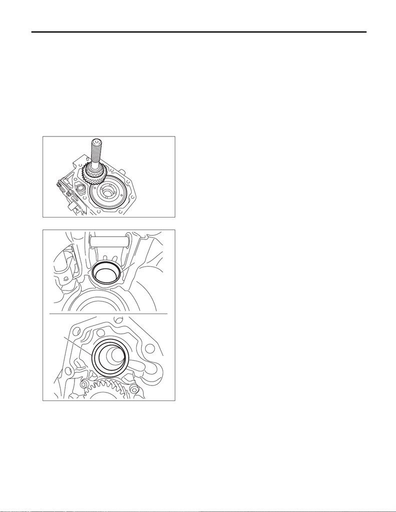

6MT(TY75)-65

Transfer Driven Gear

MANUAL TRANSMISSION AND DIFFERENTIAL

12.Transfer Driven Gear

A: REMOVAL

1) Remove the manual transmission assembly from the vehicle. <Ref. to 6MT(TY75)-25, REMOVAL, Manual

Transmission Assembly.>

2) Remove the back-up light switch and the neutral position switch. <Ref. to 6MT(TY75)-45, REMOVAL,

Switches and Harness.>

3) Remove the transfer case together with the extension case assembly. <Ref. to 6MT(TY75)-51, REMOV-

AL, Transfer Case and Extension Case Assembly.>

4) Remove the extension case assembly. <Ref. to 6MT(TY75)-51, REMOVAL, Transfer Case and Extension

Case Assembly.>

5) Remove the transfer driven gear and center differential as a unit.

6) Remove the taper roller bearing outer race.

MT-01893

MT-02461

(A)

(B)

(A) Taper roller bearing (transfer case side) outer race

(B) Taper roller bearing (extension case side) outer race

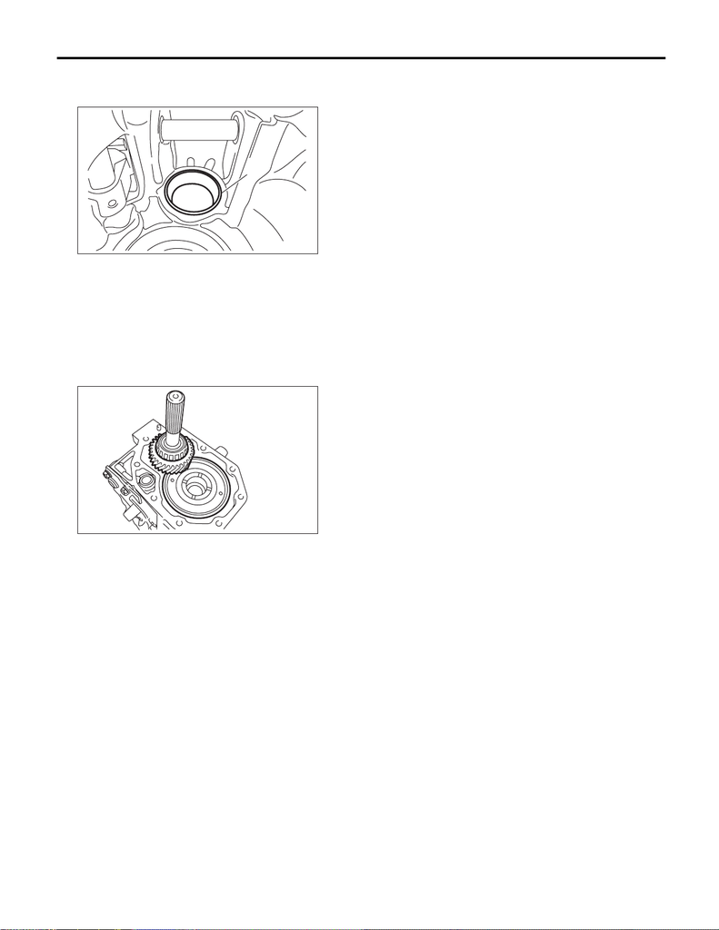

6MT(TY75)-66

Transfer Driven Gear

MANUAL TRANSMISSION AND DIFFERENTIAL

B: INSTALLATION

1) Install the taper roller bearing (transfer case side) outer race.

2) Apply a coat of grease to the taper roller bearing (transfer case side) of transfer driven gear and the roller

rolling surface of the taper roller bearing (extension case side).

Grease:

NICHIMOLY N-130 or equivalent

3) Install the transfer driven gear and center differential as a unit.

4) Select the adjusting washer. <Ref. to 6MT(TY75)-53, INSTALLATION, Transfer Case and Extension Case

Assembly.>

5) Install the selected adjusting washer and taper roller bearing (extension case side) outer race to the ex-

tension case.

6) Install the transfer case and the extension case assembly. <Ref. to 6MT(TY75)-53, INSTALLATION,

Transfer Case and Extension Case Assembly.>

7) Install the back-up light switch and the neutral position switch. <Ref. to 6MT(TY75)-46, INSTALLATION,

Switches and Harness.>

8) Install the manual transmission assembly to the vehicle. <Ref. to 6MT(TY75)-30, INSTALLATION, Manual

Transmission Assembly.>

MT-02462

(A)

(A) Taper roller bearing (transfer case side) outer

race

MT-01893

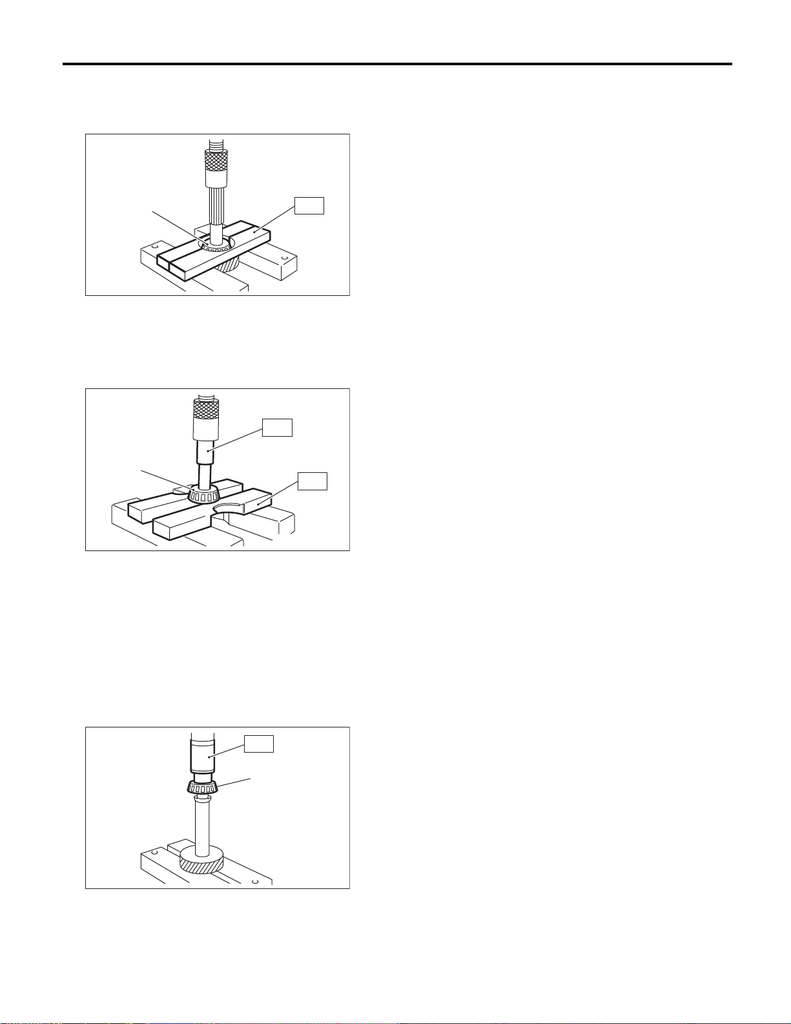

6MT(TY75)-67

Transfer Driven Gear

MANUAL TRANSMISSION AND DIFFERENTIAL

C: DISASSEMBLY

1) Using the ST, remove the taper roller bearing (extension case side).

ST 498077000 REMOVER

2) Using ST1 and ST2, remove the taper roller bearing (transfer case side).

ST1 498077000 REMOVER

ST2 899864100 REMOVER

D: ASSEMBLY

1) Using the ST, install the taper roller bearing (transfer case side).

CAUTION:

Do not apply a load in excess of 10 kN (1 ton, 1.1 US ton, 1.0 Imp ton).

NOTE:

Be careful when handling because the taper roller bearing and the outer race are used as a set.

ST 927640000 INSTALLER

MT-00143

(A)

ST

(A) Taper roller bearing (extension case side)

MT-00144

(A)

ST1

ST2

(A) Taper roller bearing (transfer case side)

MT-00146

(A)

ST

(A) Taper roller bearing (transfer case side)

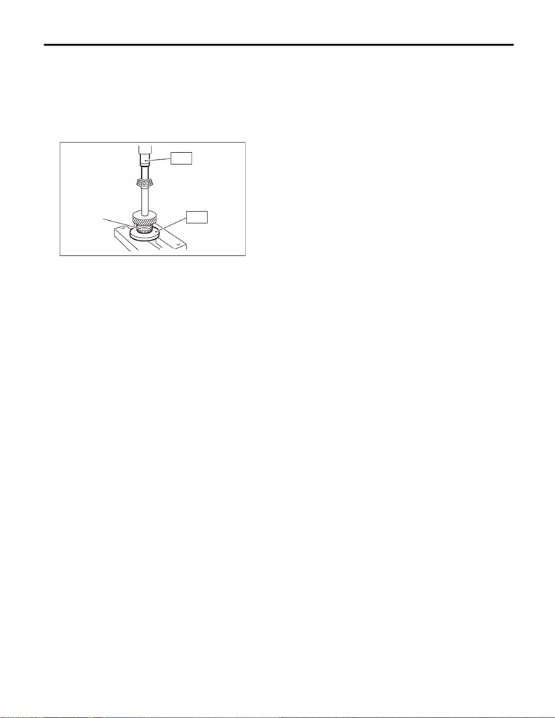

6MT(TY75)-68

Transfer Driven Gear

MANUAL TRANSMISSION AND DIFFERENTIAL

2) Using the ST, install the taper roller bearing (extension case side).

CAUTION:

Do not apply a load in excess of 10 kN (1 ton, 1.1 US ton, 1.0 Imp ton).

NOTE:

Be careful when handling because the taper roller bearing and the outer race are used as a set.

ST1 498175500 INSTALLER

ST2 899864100 REMOVER

E: INSPECTION

1) Taper roller bearing

Replace the taper roller bearing in the following cases.

• In case of broken or rusty taper roller bearings

• In case of worn or damaged taper roller bearings

• When the taper roller bearings fail to turn smoothly or emit noise in rotation after gear oil lubrication.

2) Transfer driven gear

If the tooth face of transfer driven gear and the shaft are excessively broken or damaged, replace the transfer

driven gear.

MT-00145

(A)

ST1

ST2

(A) Taper roller bearing (extension case side)